# Swiss Energy Governance Ch.14 - Fig. Vision Likert

Aya Kachi

July 2020

### Libraries

```r
library(ggplot2)
library(likert)
```

### Data

#### Main dataset

- This is the fullest dataset (the ‘main dataset’).
- Two versions (canton and non-canton) have been merged.
- Actor names mentioned in listing items have been cleaned.
- Includes the entire population of ``relevant" stakeholders (N=740), 105 more actors that were involved in the “Wasserzins” process, and 2 more respondents that submitted without out invitation. These 105 actors that were involved only in the Wasserzins case were excluded from our population criteria eventually. They were not invited to the survey either. This is why the dataset contains 847 observations.

```r
data.full <- read.csv("../data/20200625_SESHS_All.csv", sep = ",", header = T, encoding = "UTF-8")
```

#### Data cleaning

- Drop 1 obs whose progress is 0%.
- Keep all those that submitted the survey.
- Drop 2 uninvited submissions. (Pity but I’m following our population identification protocol.)
- Keep obs that are coded as “finished” (completed).

```r
data <- data.full[which(data.full$I_Participation == 1 & data.full$Progress != 0), ]
data <- data[!(data$X == "174" | data$X == "202"), ]
dim1 <- dim(data)
data <- data[which(data$Finished == 1), ]
dim2 <- dim(data)
attach(data)
```

We received 364 submissions, among which 312 completed most parts of the survey. This makes the completion rate 86%. Our analyes will be based on the completed data of N=312.

### Vision on the ES2050 goals - Survey items

To what extent do Swiss energy stakeholders find these policy goals realistic? We asked the following 8 questions.

**1. Wind** - According to the Energy Strategy 2050, around 800-900 wind turbines need to be constructed in Switzerland by 2050. All things considered at this moment, from your organization’s point of view, does this target look realistic or unrealistic?

**2. DGE** - According to the Energy Strategy 2050, deep geothermal energy (DGE) is a viable option to produce baseload electricity. All things considered at this moment, from your organization’s point of view, does a substantial increase in electricity generation capacity by DGE look realistic or more unrealistic?

**3. RE Subsidies** - According to the Energy Strategy 2050, feed-in tariffs for renewable energies will be phased out in 2022, and investment contributions and one-time payments will be phased out in 2030. All things considered at this moment, from your organization’s point of view, do you think it is realistic that the targets of the Energy Strategy 2050 will be attained in this policy environment?

**4. E-Mobility** - According to the recently published roadmap for the promotion of electric mobility, the share of electric vehicles of newly registered cars ought to reach 15 percent in 2022. All things considered at this moment, from your organization’s point of view, does this target look realistic or unrealistic?

**5. Hydropower** - Hydropower represents an important part of the Swiss electricity generation mix. All things considered at this moment, does your organisation consider the following measures to expand HP capacity in Switzerland to be realistic? …By new pumped storage.

**6. Hydropower** - …By new small hydropower plants.

**7. Hydropower** - …By expansion of existing plants.

**8. Hydropower** - …By modernization of existing plants.

Originally coded as (1) Completely realistic – (4) Completely unrealistic. We’ll reverse the scale. We’ll also convert them to factor variables as it’s required for likert bar charts.

```r
vision <- subset(data, select = c(Q19,Q22,Q25,Q28,Q31_1,Q31_2,Q31_3,Q31_4))
visionlevels <- c('Completely unrealistic', 'Rather unealistic', 'Rather realistic', 'Completely realistic')
vision.list <- c("Q19","Q22","Q25","Q28","Q31_1","Q31_2","Q31_3","Q31_4")
vision[vision.list] <- lapply(vision[vision.list], function(x) factor((5-x), labels = visionlevels))
```

New: (1) Completely unrealistic, (2) Rather unrealistic, (3) Rather realistic, (4) Completely realistic.

### Plots

#### Design elements

```r
# plot theme.
blank_themep <-  #theme_minimal()+
  theme(
    axis.title.x = element_blank(),
    axis.title.y = element_blank(),
    axis.ticks = element_blank(),
    plot.title= element_text(size=15, face="bold", hjust = 0.5, color = "black"),
    legend.title=element_text(size=11, face="bold", color = "black"),
    legend.text=element_text(size=11, color = "black"),
    legend.key.size=unit(.01,"npc"),
    axis.text.x=element_text(size=10, color = "black"),
    axis.text.y=element_text(size=11, color = "black"),
    aspect.ratio = 1/2.5
   )
```

```r
# my gray scale.
n <- 4
visioncolors <- gray.colors(n, start = 0.5, end = 0.1, gamma = 1.8)
```

#### Plot - Non-HP visions

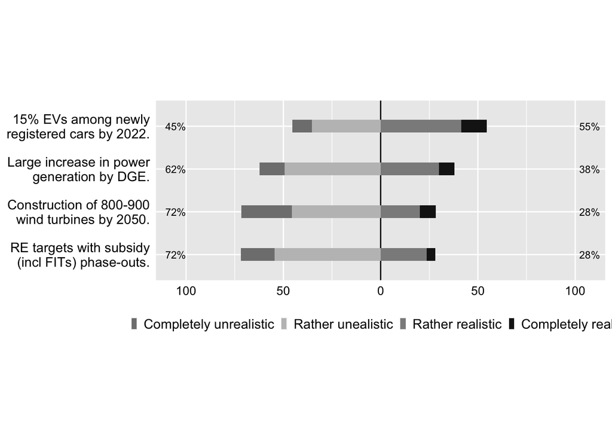

```r
options(digits=4)
what <- subset(vision, select = c(Q19,Q22,Q25,Q28))
names(what) <- c(
            Q19="Construction of 800-900 wind turbines by 2050.",
            Q22="Large increase in power generation by DGE.",
            Q25="RE targets with subsidy (incl FITs) phase-outs.",
            Q28="15% EVs among newly registered cars by 2022.")
dimwhat<- dim(na.omit(what))

likewhat <- likert(what)
plot <- likert.bar.plot(likewhat, wrap = 25, low.color = visioncolors[1], high.color = visioncolors[n], neutral.color = "grey90", legend = "", legend.position = "bottom") +
  blank_themep
plot$layers[[2]]$geom_params$width = 0.3 ## for thinner bars
plot$layers[[3]]$geom_params$width = 0.3
plot(plot)
```

The graph is based on N=303.

#### Plot - HP

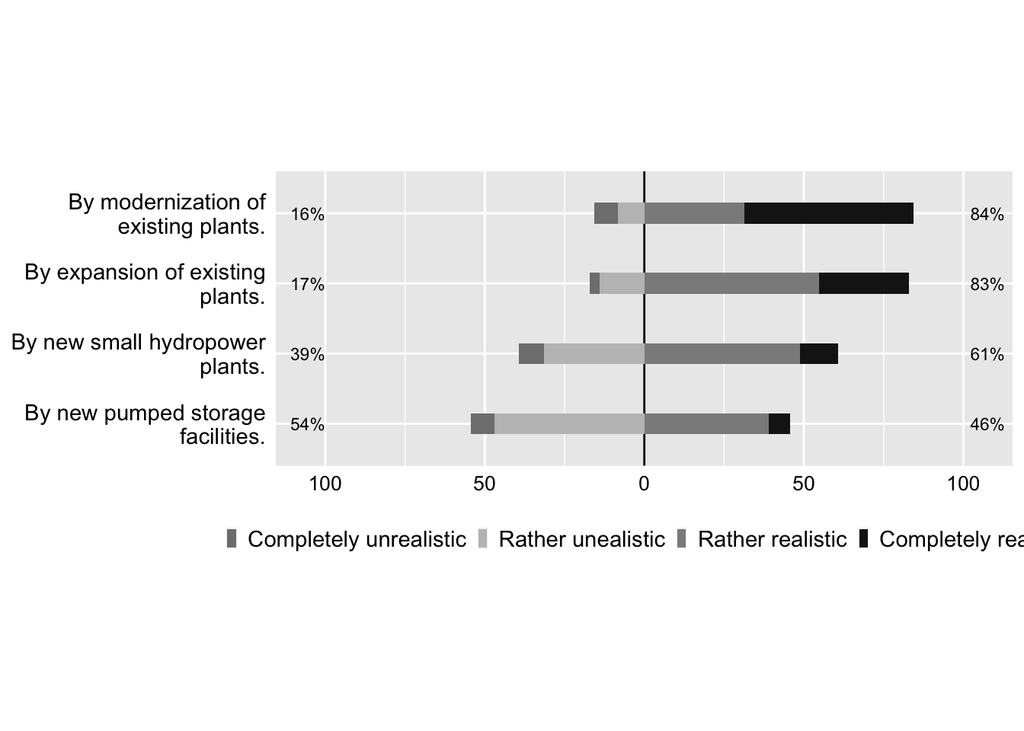

The graph is based on N=304.

### Save plots

I save low and high resolution plots for different uses.

```r
png(file="../outputs/fig_vision4_hr.png", width = 8, height = 4, units = "in", res = 300) ## hi
    plot
dev.off()
png(file="../outputs/fig_vision4_lr.png", width = 8, height = 4, units = "in", res = 70) ## low
    plot
dev.off()
png(file="../outputs/fig_vision_hp_hr.png", width = 8, height = 4, units = "in", res = 300)
    plot.hp
dev.off()
png(file="../outputs/fig_vision_hp_lr.png", width = 8, height = 4, units = "in", res = 70)
    plot.hp
dev.off()
```